# All Life Bank Customer Segmentation

### Background

AllLife Bank wants to focus on its credit card customer base in the next financial year. They have been advised by their marketing research team, that the penetration in the market can be improved. Based on this input, the Marketing team proposes to run personalized campaigns to target new customers as well as upsell to existing customers. Another insight from the market research was that the customers perceive the support services of the back poorly. Based on this, the Operations team wants to upgrade the service delivery model, to ensure that customer queries are resolved faster

##### Objective:

To identify different segments in the existing customer, based on their spending patterns as well as past interaction with the bank, using clustering algorithms, and provide recommendations to the bank on how to better market to and service these customers.

### Data Context

1. Sl_No: Primary key of the records
2. Customer Key: Customer identification number
3. Average Credit Limit: Average credit limit of each customer for all credit cards
4. Total credit cards: Total number of credit cards possessed by the customer
5. Total visits bank: Total number of visits that customer made (yearly) personally to the bank
6. Total visits online: Total number of visits or online logins made by the customer (yearly)
7. Total calls made: Total number of calls made by the customer to the bank or its customer service department (yearly

#### Importing all the required packages for the project:

```python
import pandas as pd  # importing Pandas for dataset import
import matplotlib.pyplot as plt  # importing for basic visualization and seaborn
import seaborn as sns  # importing for better visualization features
import warnings  # importing to suppress the warnings of deprecated features
import numpy as np  # importing numpy
warnings.filterwarnings("ignore")  # suppress the warnings
pd.set_option("display.max_columns", None) # Removes the limit for the number of displayed columns
pd.set_option("display.max_rows", 200) # Sets the limit for the number of displayed rows
from sklearn.preprocessing import StandardScaler # to scale the data using z-score
from scipy.spatial.distance import pdist # to compute distances
from scipy.spatial.distance import cdist # to compute distances
from sklearn.cluster import KMeans # to perform k-means clustering
from sklearn.metrics import silhouette_score # to compute silhouette scores
# to visualize the elbow curve and silhouette scores
from yellowbrick.cluster import KElbowVisualizer, SilhouetteVisualizer
# to perform hierarchical clustering, compute cophenetic correlation, and create dendrograms
from sklearn.cluster import AgglomerativeClustering
from scipy.cluster.hierarchy import dendrogram, linkage, cophenet
from sklearn.decomposition import PCA # to perform PCA
```

#### Read in the dataset using pandas

```python
# importing dataset stored in csv file and setting 1st cloumn as index
df = pd.read_excel(
    r"C:\Users\user\Desktop\AI_ML_Austin\notebook prog files\ProjectWork6\Credit Card Customer Data.xlsx"
)
# creating a copy of the data so that original data remains unchanged
cusseg1 = df.copy()
```

#### To assess the data set (Top 10)

```python
cusseg1.head(10)  # display top 10 rows
```

|  | Sl_No | Customer Key | Avg_Credit_Limit | Total_Credit_Cards | Total_visits_bank | Total_visits_online | Total_calls_made |
| --- | --- | --- | --- | --- | --- | --- | --- |
| 0 | 1 | 87073 | 100000 | 2 | 1 | 1 | 0 |
| 1 | 2 | 38414 | 50000 | 3 | 0 | 10 | 9 |
| 2 | 3 | 17341 | 50000 | 7 | 1 | 3 | 4 |
| 3 | 4 | 40496 | 30000 | 5 | 1 | 1 | 4 |
| 4 | 5 | 47437 | 100000 | 6 | 0 | 12 | 3 |
| 5 | 6 | 58634 | 20000 | 3 | 0 | 1 | 8 |
| 6 | 7 | 48370 | 100000 | 5 | 0 | 11 | 2 |
| 7 | 8 | 37376 | 15000 | 3 | 0 | 1 | 1 |
| 8 | 9 | 82490 | 5000 | 2 | 0 | 2 | 2 |
| 9 | 10 | 44770 | 3000 | 4 | 0 | 1 | 7 |

Checking random rows

```python
np.random.seed(
    1
)  # random set with seed 1, so the same set of random values can be generated everytime
cusseg1.sample(n=20)  # Print 20 random rows to check the dataset
```

|  | Sl_No | Customer Key | Avg_Credit_Limit | Total_Credit_Cards | Total_visits_bank | Total_visits_online | Total_calls_made |
| --- | --- | --- | --- | --- | --- | --- | --- |
| 547 | 548 | 38125 | 26000 | 4 | 5 | 2 | 4 |
| 353 | 354 | 94437 | 9000 | 5 | 4 | 1 | 3 |
| 499 | 500 | 65825 | 68000 | 6 | 4 | 2 | 2 |
| 173 | 174 | 38410 | 9000 | 2 | 1 | 5 | 8 |
| 241 | 242 | 81878 | 10000 | 4 | 5 | 1 | 3 |
| 341 | 342 | 70779 | 18000 | 4 | 3 | 2 | 0 |
| 647 | 648 | 79953 | 183000 | 9 | 0 | 9 | 2 |
| 218 | 219 | 28208 | 19000 | 3 | 1 | 5 | 7 |
| 120 | 121 | 16577 | 10000 | 4 | 2 | 4 | 6 |
| 134 | 135 | 31256 | 13000 | 4 | 1 | 5 | 7 |
| 442 | 443 | 14439 | 51000 | 4 | 3 | 0 | 3 |
| 546 | 547 | 44157 | 68000 | 7 | 2 | 1 | 4 |
| 460 | 461 | 94595 | 26000 | 6 | 4 | 2 | 3 |
| 248 | 249 | 44398 | 11000 | 6 | 5 | 1 | 0 |
| 132 | 133 | 34103 | 12000 | 4 | 0 | 2 | 6 |
| 214 | 215 | 55275 | 15000 | 4 | 1 | 4 | 9 |
| 501 | 502 | 61216 | 38000 | 6 | 3 | 1 | 0 |
| 479 | 480 | 36632 | 47000 | 7 | 3 | 2 | 2 |
| 637 | 638 | 88442 | 173000 | 9 | 1 | 11 | 0 |
| 484 | 485 | 29102 | 28000 | 5 | 4 | 1 | 1 |

The dataset looks consistent with the description provided in the Data Dictionary.

#### Check the shape of the provided data

```python
print(
    f"There are {cusseg1.shape[0]} rows and {cusseg1.shape[1]} columns."
)  # f-string
```

```
There are 660 rows and 7 columns.
```

#### Check datatype count

```python
cusseg1.dtypes.value_counts()  # Gives count of the different datatype in dataset
```

```
int64    7
dtype: int64
```

#### Get the complete info of the dataset

```python
cusseg1.info()  # display complete info
```

```
<class 'pandas.core.frame.DataFrame'>
RangeIndex: 660 entries, 0 to 659
Data columns (total 7 columns):
 #   Column               Non-Null Count  Dtype
---  ------               --------------  -----
 0   Sl_No                660 non-null    int64
 1   Customer Key         660 non-null    int64
 2   Avg_Credit_Limit     660 non-null    int64
 3   Total_Credit_Cards   660 non-null    int64
 4   Total_visits_bank    660 non-null    int64
 5   Total_visits_online  660 non-null    int64
 6   Total_calls_made     660 non-null    int64
dtypes: int64(7)
memory usage: 36.2 KB
```

#### Describe all columns

```python
cusseg1.describe(
    include="all"
).T  #describe all dataset. Use transpose so column wise details can be view from top to bottom
```

|  | count | mean | std | min | 25% | 50% | 75% | max |
| --- | --- | --- | --- | --- | --- | --- | --- | --- |
| Sl_No | 660.0 | 330.500000 | 190.669872 | 1.0 | 165.75 | 330.5 | 495.25 | 660.0 |
| Customer Key | 660.0 | 55141.443939 | 25627.772200 | 11265.0 | 33825.25 | 53874.5 | 77202.50 | 99843.0 |
| Avg_Credit_Limit | 660.0 | 34574.242424 | 37625.487804 | 3000.0 | 10000.00 | 18000.0 | 48000.00 | 200000.0 |
| Total_Credit_Cards | 660.0 | 4.706061 | 2.167835 | 1.0 | 3.00 | 5.0 | 6.00 | 10.0 |
| Total_visits_bank | 660.0 | 2.403030 | 1.631813 | 0.0 | 1.00 | 2.0 | 4.00 | 5.0 |
| Total_visits_online | 660.0 | 2.606061 | 2.935724 | 0.0 | 1.00 | 2.0 | 4.00 | 15.0 |
| Total_calls_made | 660.0 | 3.583333 | 2.865317 | 0.0 | 1.00 | 3.0 | 5.00 | 10.0 |

1. There are 660 rows and 7 columns.(Int64 : 7, Float64: 0 and Object 0)
2. There are no missing values.

## EDA

```python
# function to plot a boxplot and a histogram along the same scale.
def histogram_boxplot(data, feature, figsize=(12, 7), kde=False, bins=None):
    f2, (ax_box2, ax_hist2) = plt.subplots(
        nrows=2,  # Number of rows of the subplot grid= 2
        sharex=True,  # x-axis will be shared among all subplots
        gridspec_kw={"height_ratios": (0.25, 0.75)},
        figsize=figsize,
    )  # creating the 2 subplots
    sns.boxplot(
        data=data, x=feature, ax=ax_box2, showmeans=True, color="violet"
    )  # boxplot will be created and a star will indicate the mean value of the column
    sns.histplot(
        data=data, x=feature, kde=kde, ax=ax_hist2, bins=bins, palette="winter"
    ) if bins else sns.histplot(
        data=data, x=feature, kde=kde, ax=ax_hist2
    )  # For histogram
    ax_hist2.axvline(
        data[feature].mean(), color="green", linestyle="--"
    )  # Add mean to the histogram
    ax_hist2.axvline(
        data[feature].median(), color="black", linestyle="-"
    )  # Add median to the histogram
```

```python
# function to label barplot
def labeled_barplot(data, feature, perc=False, n=None):
    total = len(data[feature])  # length of the column
    count = data[feature].nunique()
    if n is None:
        plt.figure(figsize=(count + 1, 5))
    else:
        plt.figure(figsize=(n + 1, 5))

    plt.xticks(rotation=90, fontsize=15)
    ax = sns.countplot(
        data=data,
        x=feature,
        palette="Paired",
        order=data[feature].value_counts().index[:n].sort_values(),
    )

    for p in ax.patches:
        if perc == True:
            label = "{:.1f}%".format(
                100 * p.get_height() / total
            )  # percentage of each class of the category
        else:
            label = p.get_height()  # count of each level of the category

        x = p.get_x() + p.get_width() / total  # width of the plot
        y = p.get_y() + p.get_height() + 1.5  # height of the plot

        ax.annotate(label, (x, y), size=12, rotation=0)  # annotate the percentage

    plt.show()  # show the plot
```

### Data Analysis: Univariate Analysis

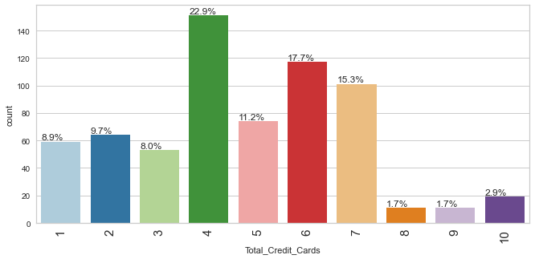

```python
labeled_barplot(cusseg1, "Total_Credit_Cards", perc=True)  # barplot
```

Almost 70% of customers have 4 or more cards. Highest number of customer have 4 cards.

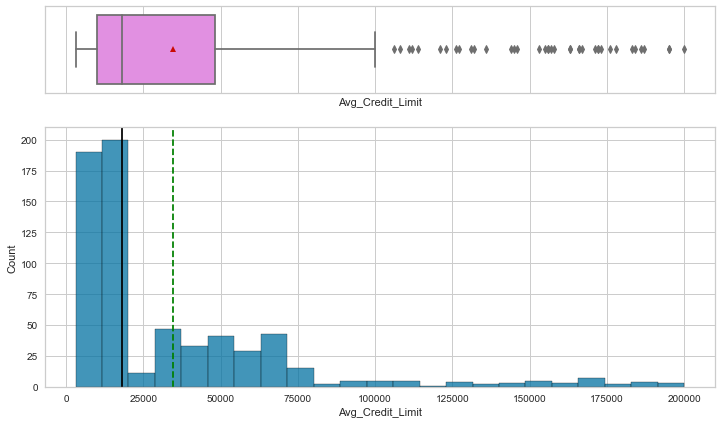

```python
histogram_boxplot(cusseg1, "Avg_Credit_Limit")  # boxplot
```

Credit Limit distribution is right skewed There are many outliers in the distribution for this variable

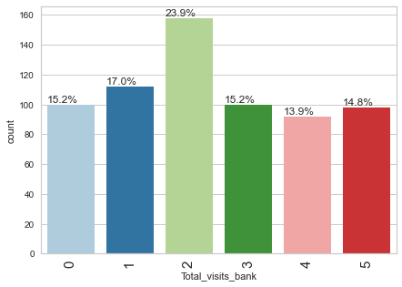

```python
labeled_barplot(cusseg1, "Total_visits_bank", perc=True)  # barplot
```

Almost 85% of customer visit bank

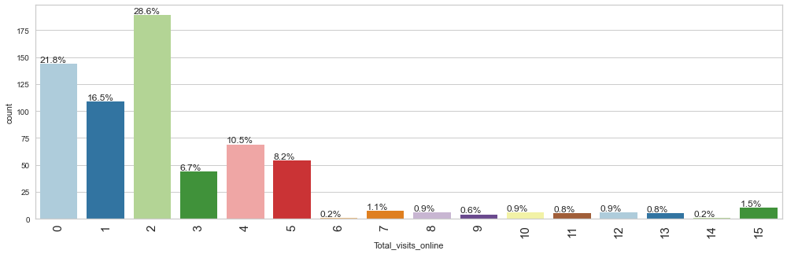

```python
labeled_barplot(cusseg1, "Total_visits_online", perc=True)  # barplot
```

Almost 80% customer use online banking facilities

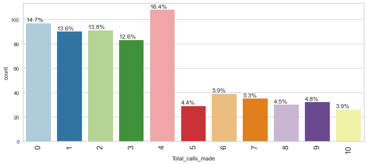

```python
labeled_barplot(cusseg1, "Total_calls_made", perc=True)  # barplot
```

Almost 85% of customer use customer service calls

## Data Analysis: Bivariate Analysis

The pair plot between the values in dataset show the overall distribution against each of the columns. This give an overall view against the selected dataset values.

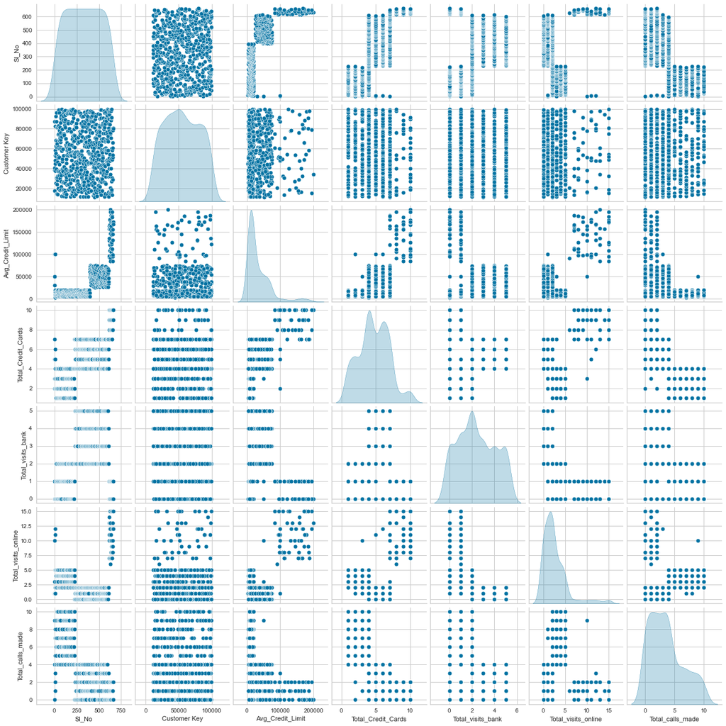

```python
sns.pairplot(cusseg1, diag_kind="kde")
# pair plot multiple pair wise bivariate distributions
```

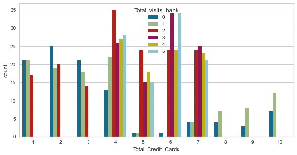

```python
plt.figure(figsize=(10, 5))
sns.countplot(x="Total_Credit_Cards", hue="Total_visits_bank", data=cusseg1)
# plot to assess important variables
```

Most customer who own only 1-4 cards are less likely to visit bank that those having more than 4 cards

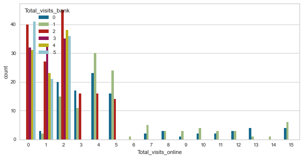

```python
plt.figure(figsize=(10, 5))
sns.countplot(x="Total_visits_online", hue="Total_visits_bank", data=cusseg1)
# plot to assess important variables
```

Those who visit online 6 or more time are less frequent visitors of bank.

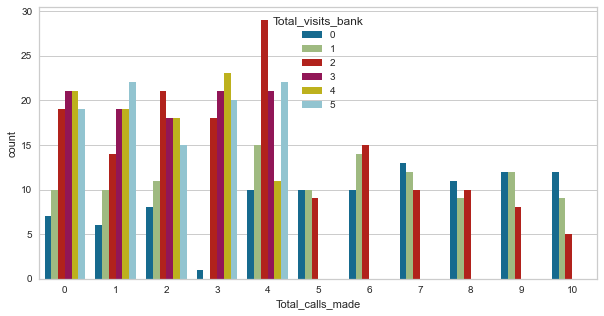

```python
plt.figure(figsize=(10, 5))
sns.countplot(x="Total_calls_made", hue="Total_visits_bank", data=cusseg1)
# plot to assess important variables
```

The number of calls mode is 5 or more the frequency of bank visits decreases.

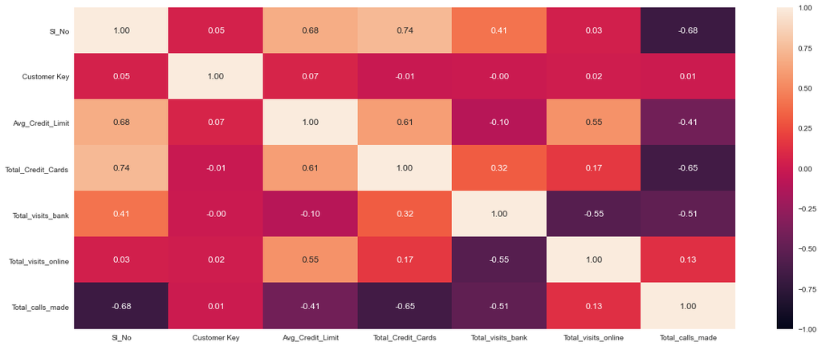

```python
plt.figure(figsize=(20, 8))
sns.heatmap(cusseg1.corr(), annot=True, vmin=-1, vmax=1, fmt=".2f")  # Heatmap
plt.show()
```

### Insights based on EDA

1. Almost 70% of customers have 4 or more cards. Highest number of customer have 4 cards.
2. Credit Limit distribution is right skewed There are many outliers in the distribution for this variable
3. Almost 85% of customer visit bank
4. Almost 80% customer use online banking facilities
5. Almost 85% of customer use customer service calls
6. Most customer who own only 1-4 cards are less likely to visit bank that those having more than 4 cards
7. Those who visit online 6 or more time are less frequent visitors of bank.
8. The number of calls mode is 5 or more the frequency of bank visits decreases.

### Data Pre-Processing

#### Checking for missing values in the data

```python
cusseg1.isnull().sum()
```

```
Sl_No                  0
Customer Key           0
Avg_Credit_Limit       0
Total_Credit_Cards     0
Total_visits_bank      0
Total_visits_online    0
Total_calls_made       0
dtype: int64
```

#### Check for duplicate data

```python
# let's check for duplicate values in the data
cusseg1.duplicated().sum()
```

```
0
```

**Number of unique values in each column**

```python
cusseg1.nunique()
```

```
Sl_No                  660
Customer Key           655
Avg_Credit_Limit       110
Total_Credit_Cards      10
Total_visits_bank        6
Total_visits_online     16
Total_calls_made        11
dtype: int64
```

```python
# creating a copy of the data so that original data remains unchanged
cusseg2 = cusseg1.copy()
```

```python
# selecting numerical columns
num_col = cusseg2.select_dtypes(include=np.number).columns.tolist()
```

```python
sc = StandardScaler()
subset_scaled_df = pd.DataFrame(
    sc.fit_transform(cusseg2.drop(["Sl_No", "Customer Key"], axis=1)),
    columns=cusseg2.drop(["Sl_No", "Customer Key"], axis=1).columns,
)
subset_scaled_df.head()
```

|  | Avg_Credit_Limit | Total_Credit_Cards | Total_visits_bank | Total_visits_online | Total_calls_made |
| --- | --- | --- | --- | --- | --- |
| 0 | 1.740187 | -1.249225 | -0.860451 | -0.547490 | -1.251537 |
| 1 | 0.410293 | -0.787585 | -1.473731 | 2.520519 | 1.891859 |
| 2 | 0.410293 | 1.058973 | -0.860451 | 0.134290 | 0.145528 |
| 3 | -0.121665 | 0.135694 | -0.860451 | -0.547490 | 0.145528 |
| 4 | 1.740187 | 0.597334 | -1.473731 | 3.202298 | -0.203739 |

### K-means Clustering

```
Number of Clusters: 1 	Average Distortion: 2.0069222262503614
Number of Clusters: 2 	Average Distortion: 1.4571553548514269
Number of Clusters: 3 	Average Distortion: 1.1466276549150365
Number of Clusters: 4 	Average Distortion: 1.0463825294774465
Number of Clusters: 5 	Average Distortion: 0.990772333470802
Number of Clusters: 6 	Average Distortion: 0.9430843103448057
Number of Clusters: 7 	Average Distortion: 0.9094290022428964
Number of Clusters: 8 	Average Distortion: 0.8891380888508975
```

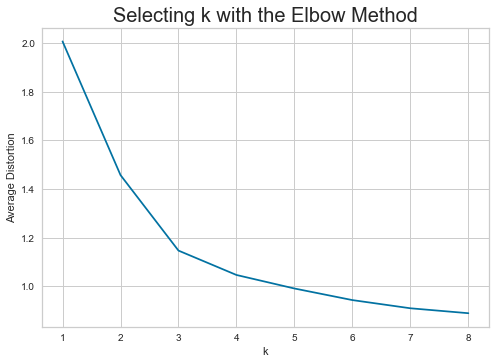

```python
clusters = range(1, 9)
meanDistortions = []

for k in clusters:
    model = KMeans(n_clusters=k)
    model.fit(subset_scaled_df)
    prediction = model.predict(subset_scaled_df)
    distortion = (
        sum(
            np.min(cdist(subset_scaled_df, model.cluster_centers_, "euclidean"), axis=1)
        )
        / subset_scaled_df.shape[0]
    )

    meanDistortions.append(distortion)

    print("Number of Clusters:", k, "\tAverage Distortion:", distortion)

plt.plot(clusters, meanDistortions, "bx-")
plt.xlabel("k")
plt.ylabel("Average Distortion")
plt.title("Selecting k with the Elbow Method", fontsize=20)
```